# Introduction to R for Economic Analysis

Inter-American Development Bank Workshop

Angelo Mazzocca

GDP Growth Nowcasting Workshop | Trinidad and Tobago

26 October 2026

## Learning Objectives

- Understand the **R language**
- Work with **data types** and **data structures**
- Import and export data
- Bring daily and quarterly series to **one frequency**
- Use **tidyverse** for data manipulation
- Visualize with **ggplot2**

## Why R?

- Dominant in academic econometrics
- Excellent for regression, panel data, and time series (`plm`, `forecast`, `vars`)
- **tidyverse** is an elegant framework for data manipulation
- **ggplot2** produces publication-ready graphics
- The classical nowcasting models of this workshop (DFM, MIDAS, MF-BVAR) run in R

# The language

Part 1

Operators, types, structures

## Operators

- Arithmetic operators

```r
2 + 5
```

```
[1] 7
```

```r
2 * 5
```

```
[1] 10
```

```r
2^5
```

```
[1] 32
```

- Logical operators

```r
2 + 5 > 2 * 5
```

```
[1] FALSE
```

```r
2^5 != 2 * 5
```

```
[1] TRUE
```

- Assignment operator

```r
country <- "Trinidad and Tobago"
country
```

```
[1] "Trinidad and Tobago"
```

## Data types

The main data types in R are: Character (string), Numeric, and Logical (TRUE or FALSE)

```r
country <- "Trinidad and Tobago"
gdp_2026q1 <- 34645         # real GDP in 2026Q1, TT$ millions
is_island <- TRUE

class(country)
```

```
[1] "character"
```

```r
class(gdp_2026q1)
```

```
[1] "numeric"
```

```r
class(is_island)
```

```
[1] "logical"
```

## Data structures

- **Vectors**: items of the same type, combined with `c()`

```r
x <- c(10, 20, 30)
x * 2
```

```
[1] 20 40 60
```

- **Lists**: can hold different data types, combined with `list()`

```r
x <- list(10, "Brent", 10 < 20)
str(x)
```

```
List of 3
 $ : num 10
 $ : chr "Brent"
 $ : logi TRUE
```

- **Matrices**: two-dimensional, same data type

```r
x <- matrix(c(1,2,3,4,5,6), nrow = 3, ncol = 2)
x
```

```
     [,1] [,2]
[1,]    1    4
[2,]    2    5
[3,]    3    6
```

## Data frames

Data displayed as a table. Each column must contain the same data type, but columns can differ from each other.

```r
df <- data.frame(
  country = c("Trinidad and Tobago", "Barbados",
              "Jamaica", "Guyana"),
  energy  = c(TRUE, FALSE, FALSE, TRUE)
)
df
```

```
              country energy
1 Trinidad and Tobago   TRUE
2            Barbados  FALSE
3             Jamaica  FALSE
4              Guyana   TRUE
```

Use `str()` to inspect column types:

```r
str(df)
```

```
'data.frame':   4 obs. of  2 variables:
 $ country: chr  "Trinidad and Tobago" "Barbados" "Jamaica" "Guyana"
 $ energy : logi  TRUE FALSE FALSE TRUE
```

## Selecting values

- `$` operator: access a column by name

```r
df$country
```

```
[1] "Trinidad and Tobago" "Barbados"            "Jamaica"
[4] "Guyana"
```

- `[]` operator: access rows, columns, or single values

```r
df["country"]
```

```
              country
1 Trinidad and Tobago
2            Barbados
3             Jamaica
4              Guyana
```

```r
df[1, ]
```

```
              country energy
1 Trinidad and Tobago   TRUE
```

```r
df[1, "country"]
```

```
[1] "Trinidad and Tobago"
```

## Conditionals

The `if` statement runs a block when the condition is TRUE. `else if` and `else` handle the remaining cases.

```r
brent <- 65

if(brent >= 80){
  print("High oil price")
} else if(brent >= 60){
  print("Medium oil price")
} else {
  print("Low oil price")
}
```

```
[1] "Medium oil price"
```

## Loops

- **For loop**: iterate over a sequence (here, the rows of `df`, with an `if` inside)

```r
for (i in 1:nrow(df)) {
  if (df$energy[i]) {
    print(paste(df$country[i], "is an energy exporter"))
  } else {
    print(paste(df$country[i], "is not"))
  }
}
```

```
[1] "Trinidad and Tobago is an energy exporter"
[1] "Barbados is not"
[1] "Jamaica is not"
[1] "Guyana is an energy exporter"
```

- **While loop**: run as long as condition is TRUE

```r
i <- 1
while(i < 6){
  print(i)
  i <- i + 1
}
```

```
[1] 1
[1] 2
[1] 3
[1] 4
[1] 5
```

# Data with the tidyverse

Part 2

Import, aggregate, join, summarise

## Working directory

The working directory is the default location R uses to read and save files. Work from the folder that holds `act1_r_basics_activity.R`, so that `../data/` resolves.

```r
# Check your current working directory
getwd()

# In VS Code / RStudio: Session -> Set Working Directory -> To Source File Location,
# or set it by hand (update path as needed)
setwd("C:/path/to/public/activity")
```

## The data

Three series for Trinidad and Tobago, at three frequencies and in three files:

| File | Series | Frequency |
| --- | --- | --- |
| `gdp.csv` | Real GDP, TT$ millions | Quarterly |
| `eia_brent.csv` | Brent crude, US$ per barrel | Daily |
| `ntl_shape.csv` | Night-time lights over the whole country | Daily |

GDP is stamped on the **first day of the quarter’s last month** (2025Q4 is `2025-12-01`).

## Tidyverse

A collection of R packages for data analysis built around the pipe operator `%>%`, which feeds the output of one function into the next.

- `filter()`: select rows matching a condition
- `select()`: keep some columns
- `rename()`: change a column’s name (`new = old`)
- `mutate()`: create or update columns
- `arrange()`: sort rows ascending or descending
- `summarise()`: collapse rows into summary statistics (by group with `group_by()`)

```r
df %>%
  filter(energy) %>%
  mutate(exporter = "energy") %>%
  arrange(country) %>%
  select(country, exporter)
```

```
              country exporter
1              Guyana   energy
2 Trinidad and Tobago   energy
```

## Import

Use `read_csv()` (from `readr`, part of the tidyverse) to import CSV files. Dates in ISO format (`2025-12-01`) are parsed automatically. Always check the structure after importing.

```r
gdp <- read_csv("../data/gdp.csv")
gdp <- gdp %>% rename(gdp = rgdp)
str(gdp)
```

```
spc_tbl_ [57 × 2] (S3: spec_tbl_df/tbl_df/tbl/data.frame)
 $ date: Date[1:57], format: "2012-03-01" "2012-06-01" ...
 $ gdp : num [1:57] 41772 42032 42480 41713 41987 ...
 - attr(*, "spec")=
  .. cols(
  ..   date = col_date(format = ""),
  ..   rgdp = col_double()
  .. )
 - attr(*, "problems")=<externalptr>
```

```r
tail(gdp)
```

```
# A tibble: 6 × 2
  date          gdp
  <date>      <dbl>
1 2024-12-01 38169.
2 2025-03-01 35286.
3 2025-06-01 36812.
4 2025-09-01 37594.
5 2025-12-01 37704.
6 2026-03-01 34645.
```

## Import: night-time lights

`select()` keeps only the columns you need.

```r
ntl <- read_csv("../data/ntl_shape.csv") %>% select(date, shape_mean)
head(ntl)
```

```
# A tibble: 6 × 2
  date       shape_mean
  <date>          <dbl>
1 2012-01-19       8.29
2 2012-01-20       9.94
3 2012-01-21       7.93
4 2012-01-22       7.55
5 2012-01-23       6.43
6 2012-01-24       7.51
```

If a file stores dates as text in another format, `lubridate` converts them: `mdy("03/31/2025")`, `dmy("31/03/2025")`, `ymd("2025-03-31")`.

## Activity 1

**Import the Brent price, and rename its column `brent price` to `brent`**

Names with spaces need back-ticks in R: `` `brent price` ``.

```r
oil <- ___
oil <- oil %>% rename(brent = ___)
tail(oil)
```

## Activity 1: Solution

```r
oil <- read_csv("../data/eia_brent.csv")
oil <- oil %>% rename(brent = `brent price`)
tail(oil)
```

```
# A tibble: 6 × 2
  date       brent
  <date>     <dbl>
1 2026-10-07  126
2 2026-10-08  130.
3 2026-10-09  130.
4 2026-10-12  130.
5 2026-10-13  126.
6 2026-10-14  127.
```

## Dates: daily to quarterly

Daily series must be averaged into quarters, and stamped like GDP, before they can be joined.

- `floor_date(date, "quarter")`: first day of the quarter (`2025-10-01`)
- `%m+% months(2)`: two months later (`2025-12-01`)

```r
ntl_q <- ntl %>%
  mutate(date = floor_date(date, "quarter") %m+% months(2)) %>%
  group_by(date) %>%
  summarise(ntl = mean(shape_mean, na.rm = TRUE), days = n())
tail(ntl_q)
```

```
# A tibble: 6 × 3
  date         ntl  days
  <date>     <dbl> <int>
1 2025-09-01  8.16    86
2 2025-12-01  8.61    90
3 2026-03-01  8.70    87
4 2026-06-01  8.90    86
5 2026-09-01  8.49    81
6 2026-12-01  8.65     4
```

## Activity 2

**Do the same for the oil price**

```r
oil_q <- oil %>%
  mutate(date = ___) %>%
  group_by(date) %>%
  summarise(brent = ___)
tail(oil_q)
```

## Activity 2: Solution

```r
oil_q <- oil %>%
  mutate(date = floor_date(date, "quarter") %m+% months(2)) %>%
  group_by(date) %>%
  summarise(brent = mean(brent, na.rm = TRUE))
tail(oil_q)
```

```
# A tibble: 6 × 2
  date       brent
  <date>     <dbl>
1 2025-09-01  69.0
2 2025-12-01  63.7
3 2026-03-01  80.7
4 2026-06-01 103.
5 2026-09-01  96.3
6 2026-12-01 127.
```

## Joining

`left_join()` keeps all rows from the left data frame and adds matching columns from the right, joining on a shared key column.

```r
tt <- gdp %>%
  left_join(ntl_q, by = "date") %>%
  left_join(oil_q, by = "date")
head(tt)
```

```
# A tibble: 6 × 5
  date          gdp   ntl  days brent
  <date>      <dbl> <dbl> <int> <dbl>
1 2012-03-01 41772.  8.52    65  119.
2 2012-06-01 42032.  9.27    90  108.
3 2012-09-01 42480.  9.01    92  110.
4 2012-12-01 41713.  8.26    90  110.
5 2013-03-01 41987.  8.27    90  112.
6 2013-06-01 42542.  9.32    91  103.
```

## Activity 3

**Join again, but starting from `ntl_q`. How many rows do you get, and why?**

```r
tt2 <- ___ %>%
  left_join(___, by = "date")
nrow(tt); nrow(tt2)
```

## Activity 3: Solution

```r
tt2 <- ntl_q %>%
  left_join(gdp, by = "date")
nrow(tt); nrow(tt2)
```

```
[1] 57
```

```
[1] 60
```

```r
tail(tt2)
```

```
# A tibble: 6 × 4
  date         ntl  days    gdp
  <date>     <dbl> <int>  <dbl>
1 2025-09-01  8.16    86 37594.
2 2025-12-01  8.61    90 37704.
3 2026-03-01  8.70    87 34645.
4 2026-06-01  8.90    86    NA
5 2026-09-01  8.49    81    NA
6 2026-12-01  8.65     4    NA
```

The left table decides the rows: `tt2` has one row per quarter of night-time lights, with `NA` in `gdp` wherever GDP has no matching quarter.

## Growth rates

Year-on-year growth: compare each quarter with the same quarter a year earlier (`lag(x, 4)`).

```r
tt <- tt %>%
  arrange(date) %>%
  mutate(gdp_yoy   = 100 * (gdp   / lag(gdp, 4)   - 1),
         ntl_yoy   = 100 * (ntl   / lag(ntl, 4)   - 1),
         brent_yoy = 100 * (brent / lag(brent, 4) - 1))
tail(tt %>% select(date, gdp_yoy, ntl_yoy, brent_yoy))
```

```
# A tibble: 6 × 4
  date       gdp_yoy ntl_yoy brent_yoy
  <date>       <dbl>   <dbl>     <dbl>
1 2024-12-01    3.59 -0.0536    -11.1
2 2025-03-01   -2.00  1.45       -8.50
3 2025-06-01    3.94 -0.127     -19.6
4 2025-09-01    1.15 -1.12      -13.7
5 2025-12-01   -1.22  6.37      -14.7
6 2026-03-01   -1.82  2.86        6.39
```

## Summaries

`summarise()` collapses the whole table into one row of statistics.

```r
tt %>%
  summarise(
    avg_gdp_yoy = mean(gdp_yoy, na.rm = TRUE),
    sd_gdp_yoy  = sd(gdp_yoy, na.rm = TRUE)
  )
```

```
# A tibble: 1 × 2
  avg_gdp_yoy sd_gdp_yoy
        <dbl>      <dbl>
1      -0.909       4.66
```

## Activity 4

**Filter and summarise `tt`**

```r
# (a) Keep the quarters since 2015
tt %>% filter(date >= ___)

# (b) The average Brent price since 2015
tt %>%
  filter(date >= as.Date("2015-01-01")) %>%
  summarise(avg_brent = ___)
```

## Activity 4a: Solution

**Keep the quarters since 2015**

```r
tt %>% filter(date >= as.Date("2015-01-01"))
```

```
# A tibble: 45 × 8
   date          gdp   ntl  days brent gdp_yoy ntl_yoy brent_yoy
   <date>      <dbl> <dbl> <int> <dbl>   <dbl>   <dbl>     <dbl>
 1 2015-03-01 44043.  8.09    90  54.0    1.13  -4.88     -50.1
 2 2015-06-01 43864.  8.66    91  61.7   -1.44   2.21     -43.8
 3 2015-09-01 44725.  8.33    92  50.4   -2.96   1.73     -50.5
 4 2015-12-01 45089.  7.75    92  43.6   -3.33  -3.15     -42.9
 5 2016-03-01 42577.  7.81    91  33.8   -3.33  -3.50     -37.3
 6 2016-06-01 40645.  7.88    91  45.6   -7.34  -9.04     -26.1
 7 2016-09-01 40153.  7.32    92  45.8  -10.2  -12.1       -9.21
 8 2016-12-01 42479.  7.34    91  49.1   -5.79  -5.26      12.6
 9 2017-03-01 38913.  7.36    90  53.6   -8.61  -5.78      58.4
10 2017-06-01 38958.  7.89    91  49.6   -4.15   0.156      8.75
# ℹ 35 more rows
```

## Activity 4b: Solution

**The average Brent price since 2015**

```r
tt %>%
  filter(date >= as.Date("2015-01-01")) %>%
  summarise(avg_brent = mean(brent, na.rm = TRUE))
```

```
# A tibble: 1 × 1
  avg_brent
      <dbl>
1      66.8
```

## Correlations

Correlations of year-on-year growth, pairwise (ignoring missing quarters):

```r
tt %>%
  select(gdp_yoy, ntl_yoy, brent_yoy) %>%
  cor(use = "pairwise.complete.obs")
```

```
            gdp_yoy   ntl_yoy brent_yoy
gdp_yoy   1.0000000 0.2556696 0.2136332
ntl_yoy   0.2556696 1.0000000 0.2538457
brent_yoy 0.2136332 0.2538457 1.0000000
```

# Plots with ggplot2

Part 3

Line, density and scatter plots

## ggplot2: line plot

ggplot2 builds plots layer by layer using `+`.

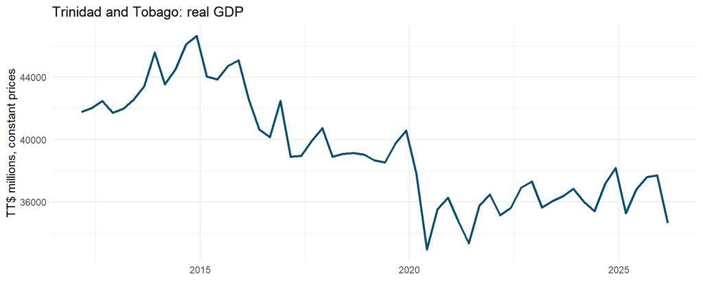

```r
ggplot(tt, aes(x = date, y = gdp)) +
  geom_line(color = "#004e70", linewidth = 1) +
  labs(title = "Trinidad and Tobago: real GDP",
       x = NULL, y = "TT$ millions, constant prices") +
  theme_minimal()
```

## ggplot2: several series

To plot several series on one chart, add one `geom_line()` per series. A label for `color` inside `aes()` builds the legend.

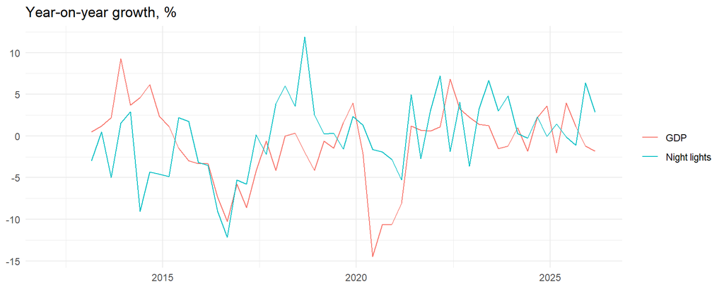

```r
ggplot(tt, aes(x = date)) +
  geom_line(aes(y = gdp_yoy, color = "GDP")) +
  geom_line(aes(y = ntl_yoy, color = "Night lights")) +
  labs(title = "Year-on-year growth, %", x = NULL, y = NULL, color = NULL) +
  theme_minimal()
```

## ggplot2: density plot

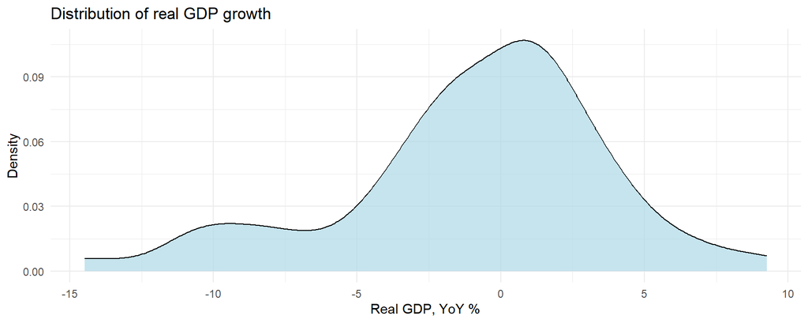

```r
ggplot(tt, aes(x = gdp_yoy)) +
  geom_density(fill = "lightblue", alpha = 0.7, na.rm = TRUE) +
  labs(title = "Distribution of real GDP growth",
       x = "Real GDP, YoY %", y = "Density") +
  theme_minimal()
```

## ggplot2: scatter plot

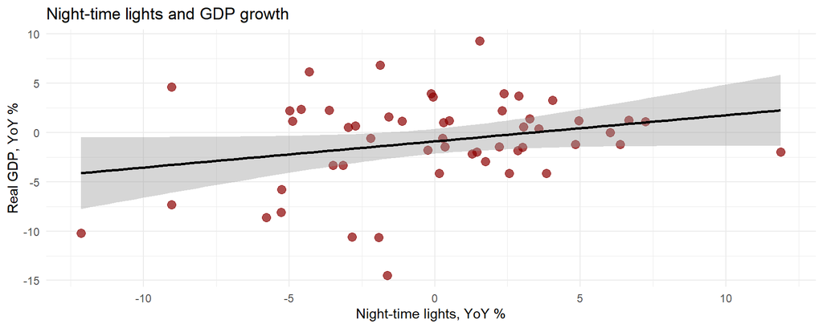

```r
ggplot(tt, aes(x = ntl_yoy, y = gdp_yoy)) +
  geom_point(color = "darkred", size = 3, alpha = 0.7) +
  geom_smooth(method = "lm", se = TRUE, color = "black") +
  labs(title = "Night-time lights and GDP growth",
       x = "Night-time lights, YoY %", y = "Real GDP, YoY %") +
  theme_minimal()
```

## Activity 5

**A scatter plot of GDP growth (y) against Brent growth (x), with a fitted line**

```r
ggplot(tt, aes(x = ___, y = ___)) +
  geom_point(color = "darkred", size = 2, alpha = 0.7) +
  geom_smooth(method = "lm", se = TRUE, color = "black") +
  labs(title = "Oil prices and GDP growth",
       x = "Brent, YoY %", y = "Real GDP, YoY %") +
  theme_minimal()
```

## Activity 5: Solution

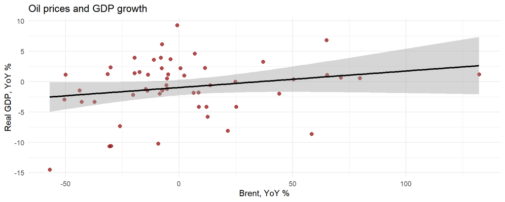

```r
ggplot(tt, aes(x = brent_yoy, y = gdp_yoy)) +
  geom_point(color = "darkred", size = 2, alpha = 0.7) +
  geom_smooth(method = "lm", se = TRUE, color = "black") +
  labs(title = "Oil prices and GDP growth",
       x = "Brent, YoY %", y = "Real GDP, YoY %") +
  theme_minimal()
```

## Export

Save the quarterly table for later with `write_csv()`.

```r
write_csv(tt, "../output/tt_quarterly.csv")
```